# MEA Acute SC TCPL Evaluation of LDH and AB results

Amy Carpenter

July 7, 2022

# Purpose —-

To confirm that the current MEA Acute TCPL sc results are as expected for the LDH and AB endpoints  
Motivation: I noticed that Acetaminophen is a hit in a cyto assay… that didn’t seem right. So we shall investigate.  
From Strickland et al, 2018: “Further, changes in MFR occurred in the absence of cytotoxicity, as only 8 compounds decreased cell viability”  
from results section: “Compounds were deemed cytotoxic if they induced greater than 20% increase in LDH release and/or decreased mitochondrial activity by more than 80%”

```r
# knitr::spin('investigations/sc_and_cytotox_endpoints_July2022/R/checkout_mea_acute_sc_and_mc_LDH_and_AB_tcpl_results_2022-07-07.R', precious  = T, doc = '^##\\s.*')
```

# Prepare data —-

```r
# Load tcpl results
# load('../../mea_nfa_vs_acute/data/mea_acute_and_dev_sc2_2022-02-10.RData')
# sc2 <- sc2[assay_type == 'acute']
load('investigations/sc_and_cytotox_endpoints_July2022/data/sc0_and_sc2_invitrodb_05042022_2022-08-03.RData')
```

# Check out activity of LDH/AB —-

```r
tcpl.cyto.res <- sc2[, .(LDH_hitc = hitc[grepl('LDH',aenm)],
                         AB_hitc = hitc[grepl('AB',aenm)]), by = .(dsstox_substance_id, chnm, casn)]
tcpl.cyto.res[, .N, by = .(LDH_hitc, AB_hitc)][order(LDH_hitc, AB_hitc)]
```

| LDH_hitc | AB_hitc | N |
| --- | --- | --- |
| 0 | 0 | 870 |
| 0 | 1 | 40 |
| 1 | 0 | 175 |
| 1 | 1 | 19 |

```r
#    LDH_hitc AB_hitc   N
# 1:        0       0 870
# 2:        0       1  40
# 3:        1       0 175
# 4:        1       1  19
```

```r
sc2[grepl('(LDH)|(AB)',aenm), .N, by = .(aenm, bmad, coff)]
```

| aenm | bmad | coff | N |
| --- | --- | --- | --- |
| CCTE_Shafer_MEA_LDH | 2.547671 | 7.643012 | 1104 |
| CCTE_Shafer_MEA_AB | 6.666138 | 19.998414 | 1104 |

```r
#                   aenm     bmad      coff    N
# 1: CCTE_Shafer_MEA_LDH 2.547671  7.643012 1104
# 2:  CCTE_Shafer_MEA_AB 6.666138 19.998414 1104
```

```r
sc2[grepl('LDH',aenm), strickland_equiv_coff := 20]
sc2[grepl('AB',aenm), strickland_equiv_coff := 80]
sc2[, strickland_equiv_hitc := as.numeric(max_med >= strickland_equiv_coff)]
```

But still, results say that only 8 compounds were a hit (compound names that had a cyto hit copied from manuscript text, I don’t see where else the cyto results were published)

```r
strickland.cyto.chnms <- c('UK-337312', 'Tributyltin chloride', 'Tributyltin methacrylate', 'Phenylmercuric acetate',
                           '9-Phenanthrol', 'Gentian Violet', 'Mercuric chloride', 'Ketoconazole')
setdiff(strickland.cyto.chnms,
        sc2$chnm)
```

```
## character(0)
```

```r
# all present, cool
sc2[, strickland_cyto_hit := as.numeric(chnm %in% strickland.cyto.chnms)]
```

Check out updated LDH results

```r
sc2[grepl('LDH',aenm), .(num_samples = .N), by = .(aenm, bmad, coff, hitc, strickland_equiv_coff, strickland_equiv_hitc, strickland_cyto_hit)][order(hitc, strickland_equiv_hitc)]
```

| aenm | bmad | coff | hitc | strickland_equiv_coff | strickland_equiv_hitc | strickland_cyto_hit | num_samples |
| --- | --- | --- | --- | --- | --- | --- | --- |
| CCTE_Shafer_MEA_LDH | 2.547671 | 7.643012 | 0 | 20 | 0 | 0 | 909 |
| CCTE_Shafer_MEA_LDH | 2.547671 | 7.643012 | 0 | 20 | 0 | 1 | 1 |
| CCTE_Shafer_MEA_LDH | 2.547671 | 7.643012 | 1 | 20 | 0 | 0 | 184 |
| CCTE_Shafer_MEA_LDH | 2.547671 | 7.643012 | 1 | 20 | 0 | 1 | 3 |
| CCTE_Shafer_MEA_LDH | 2.547671 | 7.643012 | 1 | 20 | 1 | 0 | 3 |
| CCTE_Shafer_MEA_LDH | 2.547671 | 7.643012 | 1 | 20 | 1 | 1 | 4 |

So there are 184 samples that are currently a hit for LDH, but probably shoudn’t be  
Note that strickland cyto hit could have been for LDH or AB (paper did not say) And updated AB results

```r
sc2[grepl('AB',aenm), .(num_samples = .N), by = .(aenm, bmad, coff, hitc, strickland_equiv_coff, strickland_equiv_hitc, strickland_cyto_hit)][order(hitc, strickland_equiv_hitc)]
```

| aenm | bmad | coff | hitc | strickland_equiv_coff | strickland_equiv_hitc | strickland_cyto_hit | num_samples |
| --- | --- | --- | --- | --- | --- | --- | --- |
| CCTE_Shafer_MEA_AB | 6.666138 | 19.99841 | 0 | 80 | 0 | 0 | 1045 |
| CCTE_Shafer_MEA_AB | 6.666138 | 19.99841 | 1 | 80 | 0 | 0 | 50 |
| CCTE_Shafer_MEA_AB | 6.666138 | 19.99841 | 1 | 80 | 0 | 1 | 2 |
| CCTE_Shafer_MEA_AB | 6.666138 | 19.99841 | 1 | 80 | 1 | 0 | 1 |
| CCTE_Shafer_MEA_AB | 6.666138 | 19.99841 | 1 | 80 | 1 | 1 | 6 |

And at least 50 AB hits currently that probably should not be a hit Visualize hit call situation

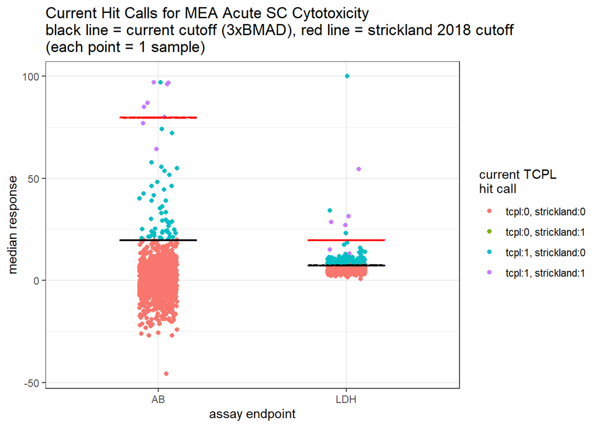

```r
sc2[, hit_desc := paste0('tcpl:',hitc,', strickland:',strickland_cyto_hit)]
sc2$hit_desc <- factor(sc2$hit_desc)
plotdat <- sc2[grepl('(LDH)|(AB)',aenm)]
plotdat[, plot_name := sub('CCTE_Shafer_MEA_','',aenm)]
ggplot(plotdat, aes(x = plot_name, y = max_med))+
  geom_jitter(aes(color =hit_desc), width = 0.1, height = 0)+
  geom_jitter(aes(y = coff), col = 'black', width = 0.2, height = 0.25, pch = '-', size = 2)+
  geom_jitter(aes(y = strickland_equiv_coff), col = 'red', width = 0.2, height = 0.25, pch = '-', size = 2)+
  scale_color_discrete(name = 'current TCPL\nhit call')+
  ylab('median response')+
  xlab('assay endpoint')+
  # scale_x_discrete(expand = expand_scale(add = c(0.5,1)))+
  # annotate(geom = 'text', x = 2.5, y = 23, label = 'Strickland2018 cutoff')+ # I don't think its 20% for both anymore
  # geom_hline(yintercept = 20)+
  # annotate(geom = 'text', x = 2.5, y = 33, label = '30% cutoff')+
  # geom_hline(yintercept = 30)+
  ggtitle('Current Hit Calls for MEA Acute SC Cytotoxicity\nblack line = current cutoff (3xBMAD), red line = strickland 2018 cutoff\n(each point = 1 sample)')+
  theme_bw()
```

```r
# ggplot(sc2[grepl('(LDH)',aenm)], aes(x = max_med))+
#   geom_histogram()+
#   geom_vline(aes(xintercept = coff), col = 'orange')+
#   geom_vline(aes(xintercept = strickland_equiv_coff))+
#   ggtitle('Current Hit Calls for MEA Acute SC ')
```

Compounds that are currently a cyto hit in tcpl, but not in strickland 2018

```r
sc2[grepl('(LDH)|(AB)',aenm) & hitc == 1 & strickland_cyto_hit == 0 & !is.na(chnm), .(aenm = sub('CCTE_Shafer_MEA_','',aenm),
                                                                                      chnm = stri_sub(chnm,1,30), max_med, coff, hitc, strickland_equiv_coff, strickland_equiv_hitc, strickland_cyto_hit)][order(hitc, strickland_equiv_hitc)][order(aenm, chnm)]
```

| aenm | chnm | max_med | coff | hitc | strickland_equiv_coff | strickland_equiv_hitc | strickland_cyto_hit |
| --- | --- | --- | --- | --- | --- | --- | --- |
| AB | 1,2-Benzisothiazolin-3-one | 44.381051 | 19.998414 | 1 | 80 | 0 | 0 |
| AB | 1,2-Phenylenediamine | 28.527857 | 19.998414 | 1 | 80 | 0 | 0 |
| AB | 2,4-Di-tert-pentylphenol | 30.109768 | 19.998414 | 1 | 80 | 0 | 0 |
| AB | 2-(Perfluorooctyl)ethanol | 27.918384 | 19.998414 | 1 | 80 | 0 | 0 |
| AB | 2-Naphthylamine | 23.063597 | 19.998414 | 1 | 80 | 0 | 0 |
| AB | 2-tert-Butyl-4-methoxyphenol | 20.021508 | 19.998414 | 1 | 80 | 0 | 0 |
| AB | 3-Iodo-2-propynyl-N-butylcarba | 53.647066 | 19.998414 | 1 | 80 | 0 | 0 |
| AB | 4-(1,1,3,3-Tetramethylbutyl)ph | 20.895262 | 19.998414 | 1 | 80 | 0 | 0 |
| AB | 4-Bromophenyl 1,4-diazabicyclo | 24.229492 | 19.998414 | 1 | 80 | 0 | 0 |
| AB | 4-Nonylphenol, branched | 35.241659 | 19.998414 | 1 | 80 | 0 | 0 |

[output cut: 226 more lines]

**I’m still slightly confused on where these values came from… (I’m just guessing 80% corresponds to 80% decrease in viability, but I don’t actually know how these values were normalized)  
There are no normalization method in TCPL  
I haven’t been able to find the srcf (NHEERL_MEA_SS_SOURCE_RAW_DATA_150422.csv), so I haven’t been able to do much forensics  
But I think reasonable to assume 80% is applicable to this data?

# Confirming normalization direction of AB and LDH values —-

I don’t know how these respone values were normalizes/what they represent  
How were these values normalized in tcpl?

```r
# NOT RUN. Just showing output as of JUly 7, 2022
# library(tcpl)
# tcplConf(drvr = 'MySQL', user = Sys.getenv('INVITRODB_USER_RO'), pass = Sys.getenv('INVITRODB_PASS_RO'), host = Sys.getenv('INVITRODB_HOST_RO'), db = 'invitrodb_05042022')
#
# shafer.aeids <- tcplLoadAeid(fld = 'asid', val = 20, add.fld = c('export_ready','internal_ready'))
# sc.cyto.aeids <- shafer.aeids[grepl('MEA_LDH',aenm) | grepl('MEA_AB',aenm), aeid]
# tcplMthdLoad(lvl = 1L, id = sc.cyto.aeids, type = 'sc')
# none
# tcplMthdLoad(lvl = 2L, id = sc.cyto.aeids, type = 'sc')
# aeid           mthd mthd_id
# 1: 2035          bmad3       1
# 2: 2036          bmad3       1
# 3: 2035 ow_bmad_nwells      20
# 4: 2036 ow_bmad_nwells      20

# sc.acid.tb <- tcplLoadAeid(fld = 'aeid', val = sc.cyto.aeids, add.fld = c('acnm','acid'))
# sc0 <- tcplPrepOtpt(tcplLoadData(lvl = 0L, fld = 'acid', type = 'sc', val = sc.acid.tb$acid))
# sc0[, .N, by = .(srcf)]
# srcf    N
# 1: NHEERL_MEA_SS_SOURCE_RAW_DATA_150422.csv 8436
```

What directino does it look like the values have been normalized?

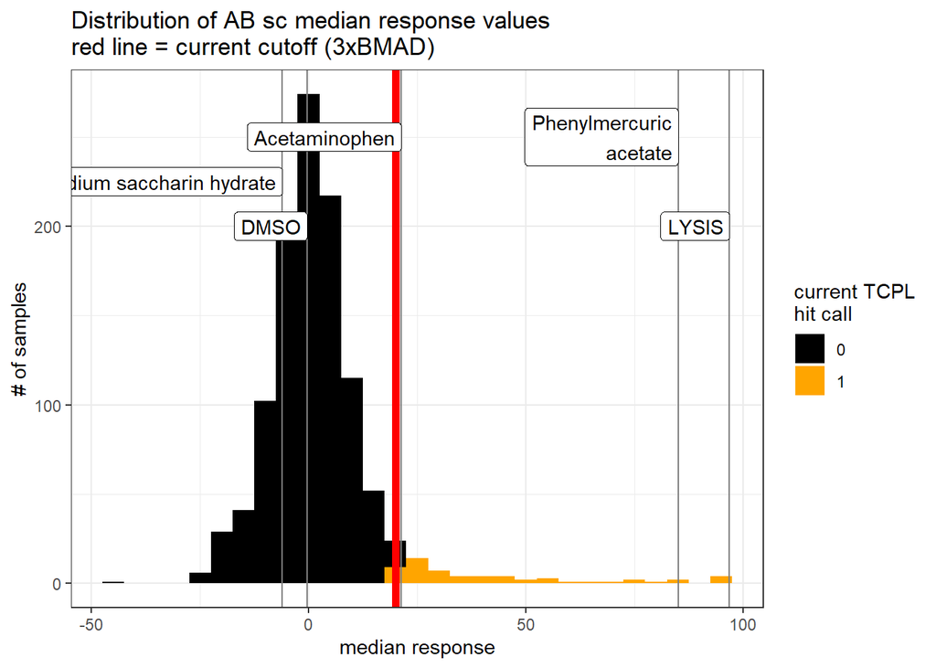

```r
ggplot(sc2[grepl('AB',aenm)], aes(x = max_med)) +
  geom_histogram(aes(fill = as.factor(hitc)), binwidth = 5)+
  xlab('median response')+
  ylab('# of samples')+
  scale_fill_manual(values = c('1' = 'orange',
                                '0' = 'black'),
                     name = 'current TCPL\nhit call')+
  geom_vline(xintercept = sc2[grepl('AB',aenm), unique(coff)], col = 'red', lwd = 2)+
  geom_vline(xintercept = sc2[spid == 'DMSO' & grepl('AB',aenm), max_med], col = 'gray50')+
  geom_vline(xintercept = sc2[spid == 'LYSIS' & grepl('AB',aenm), max_med], col = 'gray50')+
  geom_vline(xintercept = sc2[chnm == 'Phenylmercuric acetate' & grepl('AB',aenm), max_med], col = 'gray50')+
  geom_vline(xintercept = sc2[chnm == 'Acetaminophen' & grepl('AB',aenm), max_med], col = 'gray50')+
  geom_vline(xintercept = sc2[chnm == 'Sodium saccharin hydrate' & grepl('AB',aenm), max_med], col = 'gray50')+
  annotate(geom = 'label', y = 200, x = sc2[spid == 'DMSO' & grepl('AB',aenm), max_med], label = 'DMSO', hjust = 1)+
  annotate(geom = 'label', y = 200, x = sc2[spid == 'LYSIS' & grepl('AB',aenm), max_med], label = 'LYSIS', hjust = 1)+
  annotate(geom = 'label', y = 250, x = sc2[chnm == 'Phenylmercuric acetate' & grepl('AB',aenm), max_med], label = 'Phenylmercuric\nacetate', hjust = 1)+
  annotate(geom = 'label', y = 250, x = sc2[chnm == 'Acetaminophen' & grepl('AB',aenm), max_med], label = 'Acetaminophen', hjust = 1)+
  annotate(geom = 'label', y = 225, x = sc2[chnm == 'Sodium saccharin hydrate' & grepl('AB',aenm), max_med], label = 'Sodium saccharin hydrate', hjust = 1)+
  ggtitle('Distribution of AB sc median response values\nred line = current cutoff (3xBMAD)')+
  theme_bw()
```

So it really looks like the values are currently normalized such that a larger value corresponds to a greater decrease in viability

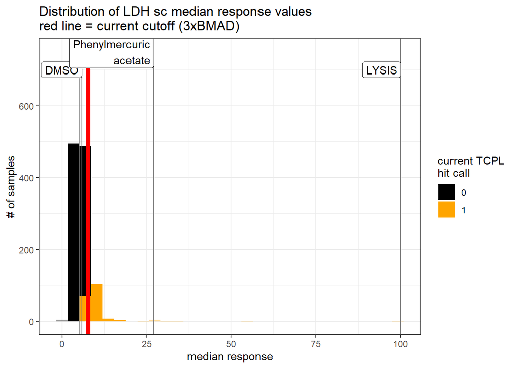

```r
ggplot(sc2[grepl('LDH',aenm)], aes(x = max_med)) +
  geom_histogram(aes(fill = as.factor(hitc)))+
  xlab('median response')+
  ylab('# of samples')+
  scale_fill_manual(values = c('1' = 'orange',
                               '0' = 'black'),
                    name = 'current TCPL\nhit call')+
  geom_vline(xintercept = sc2[grepl('LDH',aenm), unique(coff)], col = 'red', lwd = 2)+
  geom_vline(xintercept = sc2[spid == 'DMSO' & grepl('LDH',aenm), max_med], col = 'gray50')+
  geom_vline(xintercept = sc2[spid == 'LYSIS' & grepl('LDH',aenm), max_med], col = 'gray50')+
  geom_vline(xintercept = sc2[chnm == 'Phenylmercuric acetate' & grepl('LDH',aenm), max_med], col = 'gray50')+
  geom_vline(xintercept = sc2[chnm == 'Acetaminophen' & grepl('LDH',aenm), max_med], col = 'gray50')+
  geom_vline(xintercept = sc2[chnm == 'Sodium saccharin hydrate' & grepl('LDH',aenm), max_med], col = 'gray50')+
  annotate(geom = 'label', y = 200+500, x = sc2[spid == 'DMSO' & grepl('LDH',aenm), max_med], label = 'DMSO', hjust = 1)+
  annotate(geom = 'label', y = 200+500, x = sc2[spid == 'LYSIS' & grepl('LDH',aenm), max_med], label = 'LYSIS', hjust = 1)+
  annotate(geom = 'label', y = 250+500, x = sc2[chnm == 'Phenylmercuric acetate' & grepl('LDH',aenm), max_med], label = 'Phenylmercuric\nacetate', hjust = 1)+
  # annotate(geom = 'label', y = 250+500, x = sc2[chnm == 'Acetaminophen' & grepl('LDH',aenm), max_med], label = 'Acetaminophen', hjust = 1)+
  # annotate(geom = 'label', y = 225+500, x = sc2[chnm == 'Sodium saccharin hydrate' & grepl('LDH',aenm), max_med], label = 'Sodium saccharin hydrate', hjust = 1)+
  ggtitle('Distribution of LDH sc median response values\nred line = current cutoff (3xBMAD)')+
  theme_bw()
```

Also looks like larger values = greater response